# Aplicación 3.2: Inestabilidad paramétrica

- Show All Code
- Hide All Code
- View Source

En esta aplicación se estimarán varias regresiones que, tras el correspondiente contraste de estabilidad paramétrica, permiten que los parámetros estructurales del modelo de regresión varíen a lo largo de la muestra.

# Diferenciación salarial por sexo (datos de corte transversal)

En este ejemplo, al igual que en la aplicación 2.5, se usará como especificación econométrica de partida el siguiente modelo log-lineal, que se corresponde con la [ecuación de salarios de Mincer](https://es.wikipedia.org/wiki/Funci%C3%B3n_de_ingresos_de_Mincer):

$$log(SALARIO_{i}) = \beta_1 + \beta_2 EDUC_{i} + \beta_3 EXPER_{i} + e_{i}$$

donde $SALARIO$, $EDUC$ y $EXPER$ representan, respectivamente, el salario percibido, el nivel de educación y el grado de experiencia de cada uno de los 526 indviduos que componen la base muestral.

**Código R**

```r
# Lectura de librerías
library(tidyverse)
library(car)
# Lectura de datos
SAL_SEX <- read_csv("data/SAL_SEX.csv")
dim(SAL_SEX)
```

```
[1] 526   4
```

```r
str(SAL_SEX)
```

```
spc_tbl_ [526 × 4] (S3: spec_tbl_df/tbl_df/tbl/data.frame)
 $ EDUC   : num [1:526] 11 12 11 8 12 16 18 12 12 17 ...
 $ EXPER  : num [1:526] 2 22 2 44 7 9 15 5 26 22 ...
 $ MUJER  : num [1:526] 1 1 0 0 0 0 0 1 1 0 ...
 $ SALARIO: num [1:526] 3.1 3.24 3 6 5.3 ...
 - attr(*, "spec")=
  .. cols(
  ..   EDUC = col_double(),
  ..   EXPER = col_double(),
  ..   MUJER = col_double(),
  ..   SALARIO = col_double()
  .. )
 - attr(*, "problems")=<externalptr>
```

```r
head(SAL_SEX)
```

```
# A tibble: 6 × 4
   EDUC EXPER MUJER SALARIO
  <dbl> <dbl> <dbl>   <dbl>
1    11     2     1    3.1
2    12    22     1    3.24
3    11     2     0    3
4     8    44     0    6
5    12     7     0    5.3
6    16     9     0    8.75
```

```r
tail(SAL_SEX)
```

```
# A tibble: 6 × 4
   EDUC EXPER MUJER SALARIO
  <dbl> <dbl> <dbl>   <dbl>
1    12     2     0    5.65
2    16    14     1   15
3    10     2     1    2.27
4    15    13     0    4.67
5    16     5     0   11.6
6    14     5     1    3.5
```

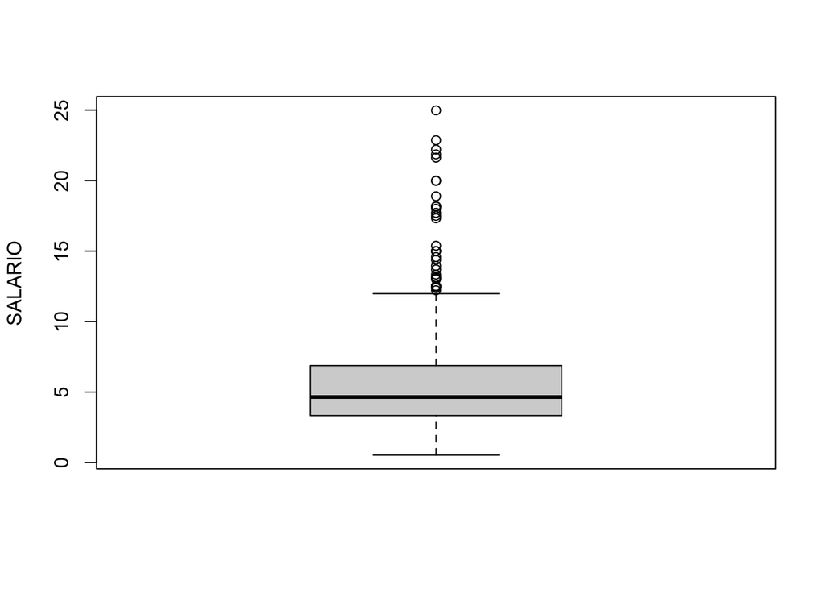

```r
# Distribución de la variable dependiente para la muestra completa
Boxplot(~SALARIO, data=SAL_SEX, main="", ylab="SALARIO", id=list(method = "none"))
```

```r
# Conversión de variable numérica MUJER (0/1) al tipo cualitativo (factor)
class(SAL_SEX$MUJER)
```

```
[1] "numeric"
```

```r
SEXO <- factor(SAL_SEX$MUJER, labels=c("Hombre", "Mujer"))
summary(SEXO)
```

```
Hombre  Mujer
   274    252
```

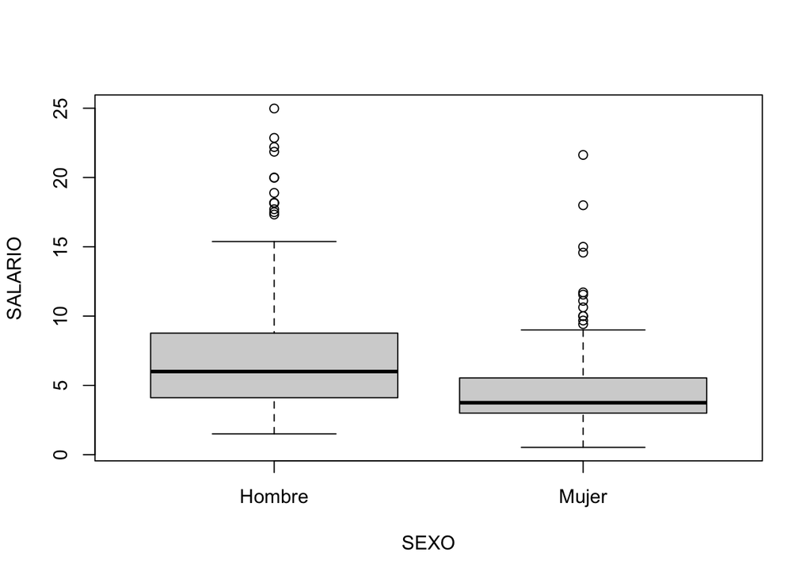

```r
# Distribución de la variable dependiente por sexo
Boxplot(SALARIO~SEXO, data=SAL_SEX, ylab="SALARIO", id=list(method = "none"))
```

```r
# Ecuación de salarios para la muestra completa
summary(lm_SAL <- lm(log(SALARIO) ~ EDUC + EXPER , data = SAL_SEX))
```

```
Call:
lm(formula = log(SALARIO) ~ EDUC + EXPER, data = SAL_SEX)

Residuals:
     Min       1Q   Median       3Q      Max
-2.05800 -0.30136 -0.04539  0.30601  1.44425

Coefficients:
            Estimate Std. Error t value Pr(>|t|)
(Intercept) 0.216854   0.108595   1.997   0.0464 *
EDUC        0.097936   0.007622  12.848  < 2e-16 ***
EXPER       0.010347   0.001555   6.653 7.24e-11 ***
---
Signif. codes:  0 '***' 0.001 '**' 0.01 '*' 0.05 '.' 0.1 ' ' 1

Residual standard error: 0.4614 on 523 degrees of freedom
Multiple R-squared:  0.2493,    Adjusted R-squared:  0.2465
F-statistic: 86.86 on 2 and 523 DF,  p-value: < 2.2e-16
```

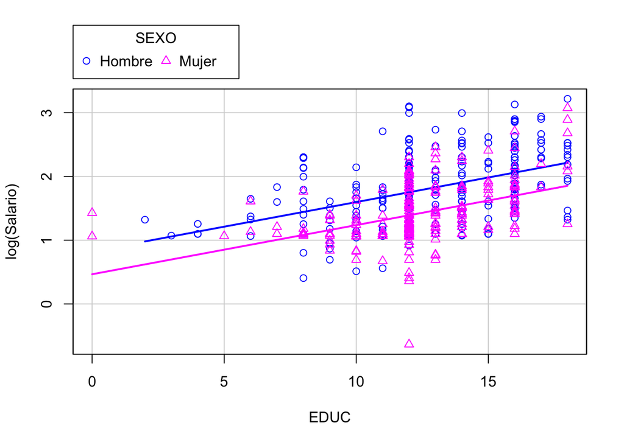

```r
# Gráficas parciales con diferenciación por sexo
scatterplot(log(SALARIO) ~ EDUC| SEXO, data=SAL_SEX, smooth=FALSE,
            boxplots=FALSE, ylab="log(Salario)")
```

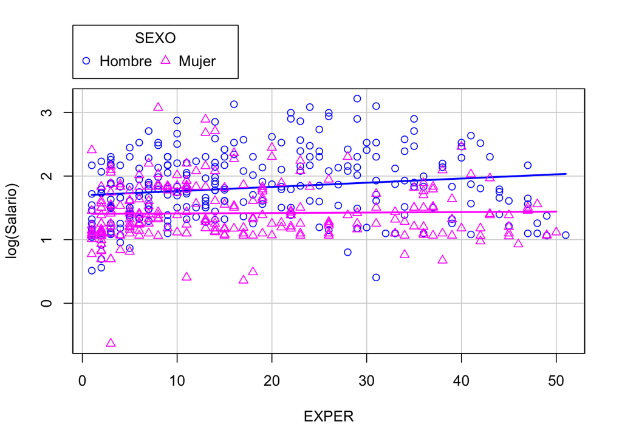

```r
scatterplot(log(SALARIO) ~ EXPER| SEXO, data=SAL_SEX, smooth=FALSE,
            boxplots=FALSE, ylab="log(Salario)")
```

```r
# Diferenciación por sexos:
# ¿existe realmente una diferencia salarial por sexos estadísticamente significativa?
# Hombres
summary(lm_SAL_h <- lm(log(SALARIO) ~ EDUC + EXPER ,
                       data = SAL_SEX[which(SAL_SEX$MUJER==0),]))
```

```
Call:
lm(formula = log(SALARIO) ~ EDUC + EXPER, data = SAL_SEX[which(SAL_SEX$MUJER ==
    0), ])

Residuals:
     Min       1Q   Median       3Q      Max
-1.20460 -0.29936 -0.01032  0.28558  1.25532

Coefficients:
            Estimate Std. Error t value Pr(>|t|)
(Intercept) 0.249794   0.144264   1.732   0.0845 .
EDUC        0.101813   0.009656  10.544  < 2e-16 ***
EXPER       0.014908   0.002148   6.941 2.87e-11 ***
---
Signif. codes:  0 '***' 0.001 '**' 0.01 '*' 0.05 '.' 0.1 ' ' 1

Residual standard error: 0.4457 on 271 degrees of freedom
Multiple R-squared:  0.3106,    Adjusted R-squared:  0.3055
F-statistic: 61.04 on 2 and 271 DF,  p-value: < 2.2e-16
```

```r
# Mujeres
summary(lm_SAL_m <- lm(log(SALARIO) ~ EDUC + EXPER ,
                       data = SAL_SEX[which(SAL_SEX$MUJER==1),]))
```

```
Call:
lm(formula = log(SALARIO) ~ EDUC + EXPER, data = SAL_SEX[which(SAL_SEX$MUJER ==
    1), ])

Residuals:
     Min       1Q   Median       3Q      Max
-1.96983 -0.21953 -0.06965  0.21896  1.22467

Coefficients:
            Estimate Std. Error t value Pr(>|t|)
(Intercept) 0.334836   0.141456   2.367   0.0187 *
EDUC        0.082314   0.010458   7.871 1.08e-13 ***
EXPER       0.004116   0.001894   2.173   0.0307 *
---
Signif. codes:  0 '***' 0.001 '**' 0.01 '*' 0.05 '.' 0.1 ' ' 1

Residual standard error: 0.399 on 249 degrees of freedom
Multiple R-squared:  0.1996,    Adjusted R-squared:  0.1932
F-statistic: 31.06 on 2 and 249 DF,  p-value: 9.089e-13
```

```r
# Comparación de coeficientes estimados
compareCoefs(lm_SAL_h, lm_SAL_m)
```

```
Calls:
1: lm(formula = log(SALARIO) ~ EDUC + EXPER, data =
  SAL_SEX[which(SAL_SEX$MUJER == 0), ])
2: lm(formula = log(SALARIO) ~ EDUC + EXPER, data =
  SAL_SEX[which(SAL_SEX$MUJER == 1), ])

            Model 1 Model 2
(Intercept)   0.250   0.335
SE            0.144   0.141

EDUC        0.10181 0.08231
SE          0.00966 0.01046

EXPER       0.01491 0.00412
SE          0.00215 0.00189
```

```r
# Test de Chow de cambio estructural
lm_SAL_int <- lm(log(SALARIO) ~ (EDUC + EXPER)*MUJER, data = SAL_SEX)
anova(lm_SAL, lm_SAL_int)
```

```
Analysis of Variance Table

Model 1: log(SALARIO) ~ EDUC + EXPER
Model 2: log(SALARIO) ~ (EDUC + EXPER) * MUJER
  Res.Df     RSS Df Sum of Sq      F    Pr(>F)
1    523 111.345
2    520  93.477  3    17.868 33.133 < 2.2e-16 ***
---
Signif. codes:  0 '***' 0.001 '**' 0.01 '*' 0.05 '.' 0.1 ' ' 1
```

```r
# Regresión diferenciada por sexos (variables de interacción)
summary(lm_SAL_int)
```

```
Call:
lm(formula = log(SALARIO) ~ (EDUC + EXPER) * MUJER, data = SAL_SEX)

Residuals:
     Min       1Q   Median       3Q      Max
-1.96983 -0.26177 -0.03718  0.25663  1.25532

Coefficients:
             Estimate Std. Error t value Pr(>|t|)
(Intercept)  0.249794   0.137237   1.820 0.069308 .
EDUC         0.101813   0.009186  11.084  < 2e-16 ***
EXPER        0.014908   0.002043   7.296 1.11e-12 ***
MUJER        0.085042   0.203534   0.418 0.676247
EDUC:MUJER  -0.019499   0.014417  -1.352 0.176818
EXPER:MUJER -0.010792   0.002868  -3.763 0.000187 ***
---
Signif. codes:  0 '***' 0.001 '**' 0.01 '*' 0.05 '.' 0.1 ' ' 1

Residual standard error: 0.424 on 520 degrees of freedom
Multiple R-squared:  0.3698,    Adjusted R-squared:  0.3637
F-statistic: 61.03 on 5 and 520 DF,  p-value: < 2.2e-16
```

**Código Python**

```python
# Lectura de librerías
import numpy as np
import pandas as pd
import matplotlib.pyplot as plt
import seaborn as sns
import statsmodels.api as sm
import statsmodels.formula.api as smf
import statsmodels.stats as smstats
import scipy as sp
# Lectura de datos
SAL_SEX = pd.read_csv("data/SAL_SEX.csv")
SAL_SEX.shape
```

```
(526, 4)
```

```python
SAL_SEX.info()
```

```
<class 'pandas.core.frame.DataFrame'>
RangeIndex: 526 entries, 0 to 525
Data columns (total 4 columns):
 #   Column   Non-Null Count  Dtype
---  ------   --------------  -----
 0   EDUC     526 non-null    int64
 1   EXPER    526 non-null    int64
 2   MUJER    526 non-null    int64
 3   SALARIO  526 non-null    float64
dtypes: float64(1), int64(3)
memory usage: 16.6 KB
```

```python
SAL_SEX.head()
```

```
   EDUC  EXPER  MUJER  SALARIO
0    11      2      1     3.10
1    12     22      1     3.24
2    11      2      0     3.00
3     8     44      0     6.00
4    12      7      0     5.30
```

```python
SAL_SEX.tail()
```

```
     EDUC  EXPER  MUJER  SALARIO
521    16     14      1    15.00
522    10      2      1     2.27
523    15     13      0     4.67
524    16      5      0    11.56
525    14      5      1     3.50
```

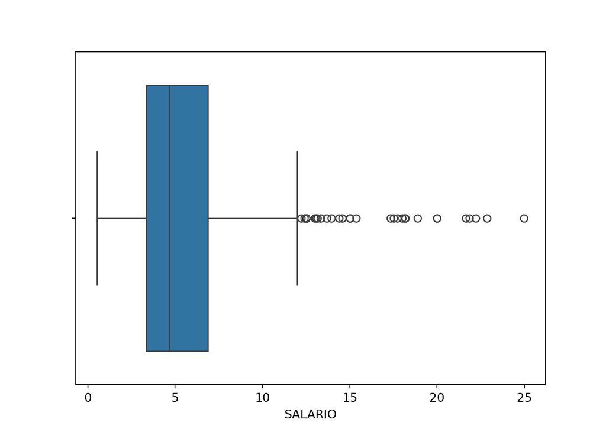

```python
# Distribución de la variable dependiente para la muestra completa
plt.figure(1)
sns.boxplot(x=SAL_SEX["SALARIO"])
plt.show()
```

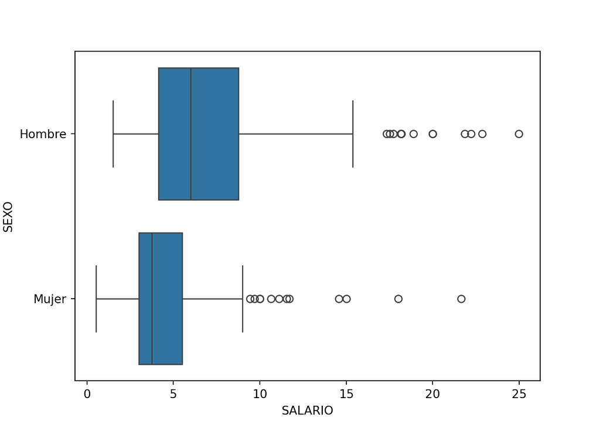

```python
# Conversión de variable numérica a cualitativa (factor)
SAL_SEX['SEXO']=SAL_SEX['MUJER'].astype('category')
SAL_SEX['SEXO']=SAL_SEX['SEXO'].cat.rename_categories(['Hombre', 'Mujer'])
# Distribución de la variable dependiente por sexo
plt.figure(2)
sns.boxplot(x=SAL_SEX["SALARIO"] , y=SAL_SEX["SEXO"])
plt.show()
```

```python
# Ecuación de salarios para la muestra total
lm_SAL = smf.ols(formula='np.log(SALARIO) ~ EDUC + EXPER', data=SAL_SEX).fit()
print(lm_SAL.summary())
```

```
                            OLS Regression Results
==============================================================================
Dep. Variable:        np.log(SALARIO)   R-squared:                       0.249
Model:                            OLS   Adj. R-squared:                  0.246
Method:                 Least Squares   F-statistic:                     86.86
Date:                Sun, 09 Feb 2025   Prob (F-statistic):           2.68e-33
Time:                        13:52:09   Log-Likelihood:                -338.01
No. Observations:                 526   AIC:                             682.0
Df Residuals:                     523   BIC:                             694.8
Df Model:                           2
Covariance Type:            nonrobust
==============================================================================
                 coef    std err          t      P>|t|      [0.025      0.975]
------------------------------------------------------------------------------
Intercept      0.2169      0.109      1.997      0.046       0.004       0.430
EDUC           0.0979      0.008     12.848      0.000       0.083       0.113
EXPER          0.0103      0.002      6.653      0.000       0.007       0.013
==============================================================================
Omnibus:                        7.740   Durbin-Watson:                   1.789
Prob(Omnibus):                  0.021   Jarque-Bera (JB):                9.485
Skew:                           0.165   Prob(JB):                      0.00872
Kurtosis:                       3.569   Cond. No.                         130.
==============================================================================

Notes:
[1] Standard Errors assume that the covariance matrix of the errors is correctly specified.
```

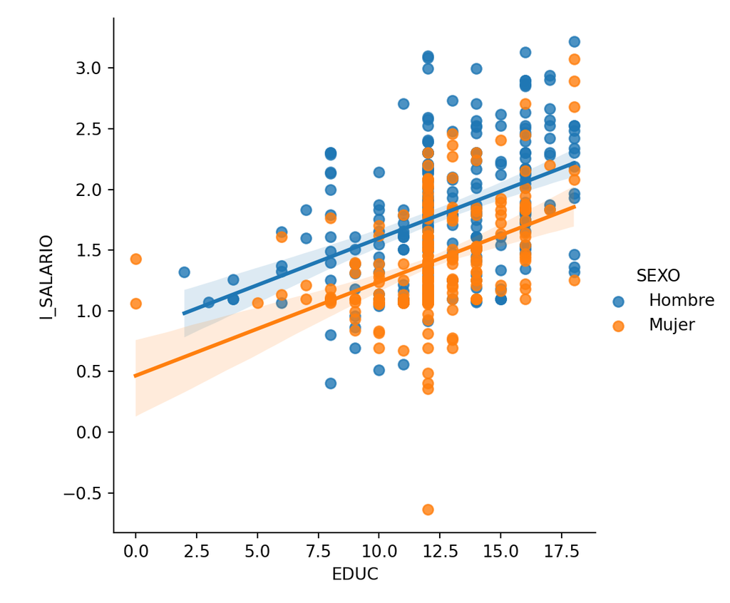

```python
# Gráficas parciales con diferenciación por sexo
SAL_SEX['l_SALARIO']=np.log(SAL_SEX['SALARIO'])
plt.figure(3)
sns.lmplot(x="EDUC", y="l_SALARIO", hue="SEXO", data=SAL_SEX);
plt.show()
```

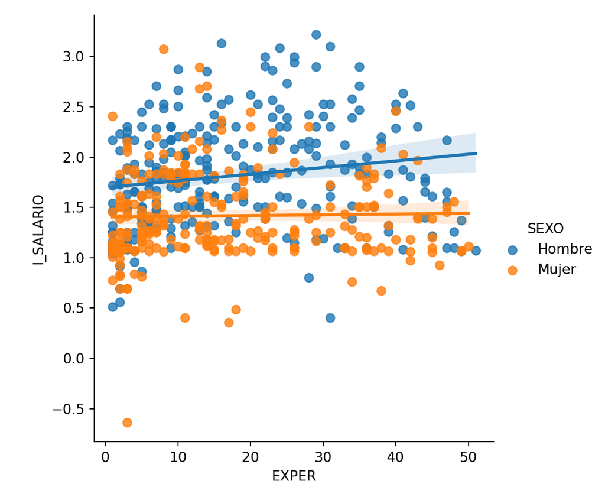

```python
plt.figure(4)
sns.lmplot(x="EXPER", y="l_SALARIO", hue="SEXO", data=SAL_SEX);
plt.show()
```

```python
# Diferenciación por sexos:
# ¿existe realmente una diferencia salarial por sexos estadísticamente significativa?
# Hombres
lm_SAL_h = smf.ols(formula='np.log(SALARIO) ~ EDUC + EXPER',
subset=(SAL_SEX['MUJER'] == 0), data=SAL_SEX).fit()
print(lm_SAL_h.summary())
```

```
                            OLS Regression Results
==============================================================================
Dep. Variable:        np.log(SALARIO)   R-squared:                       0.311
Model:                            OLS   Adj. R-squared:                  0.305
Method:                 Least Squares   F-statistic:                     61.04
Date:                Sun, 09 Feb 2025   Prob (F-statistic):           1.30e-22
Time:                        13:52:11   Log-Likelihood:                -165.86
No. Observations:                 274   AIC:                             337.7
Df Residuals:                     271   BIC:                             348.5
Df Model:                           2
Covariance Type:            nonrobust
==============================================================================
                 coef    std err          t      P>|t|      [0.025      0.975]
------------------------------------------------------------------------------
Intercept      0.2498      0.144      1.732      0.084      -0.034       0.534
EDUC           0.1018      0.010     10.544      0.000       0.083       0.121
EXPER          0.0149      0.002      6.941      0.000       0.011       0.019
==============================================================================
Omnibus:                        0.921   Durbin-Watson:                   1.872
Prob(Omnibus):                  0.631   Jarque-Bera (JB):                0.674
Skew:                           0.098   Prob(JB):                        0.714
Kurtosis:                       3.143   Cond. No.                         131.
==============================================================================

Notes:
[1] Standard Errors assume that the covariance matrix of the errors is correctly specified.
```

```python
# Mujeres
lm_SAL_m = smf.ols(formula='np.log(SALARIO) ~ EDUC + EXPER',
subset=(SAL_SEX['MUJER'] == 1), data=SAL_SEX).fit()
print(lm_SAL_m.summary())
```

```
                            OLS Regression Results
==============================================================================
Dep. Variable:        np.log(SALARIO)   R-squared:                       0.200
Model:                            OLS   Adj. R-squared:                  0.193
Method:                 Least Squares   F-statistic:                     31.06
Date:                Sun, 09 Feb 2025   Prob (F-statistic):           9.09e-13
Time:                        13:52:11   Log-Likelihood:                -124.54
No. Observations:                 252   AIC:                             255.1
Df Residuals:                     249   BIC:                             265.7
Df Model:                           2
Covariance Type:            nonrobust
==============================================================================
                 coef    std err          t      P>|t|      [0.025      0.975]
------------------------------------------------------------------------------
Intercept      0.3348      0.141      2.367      0.019       0.056       0.613
EDUC           0.0823      0.010      7.871      0.000       0.062       0.103
EXPER          0.0041      0.002      2.173      0.031       0.000       0.008
==============================================================================
Omnibus:                       17.664   Durbin-Watson:                   2.103
Prob(Omnibus):                  0.000   Jarque-Bera (JB):               56.098
Skew:                           0.007   Prob(JB):                     6.58e-13
Kurtosis:                       5.311   Cond. No.                         133.
==============================================================================

Notes:
[1] Standard Errors assume that the covariance matrix of the errors is correctly specified.
```

```python
# Regresión diferenciada por sexos (variables de interacción)
lm_SAL_int = smf.ols(formula='np.log(SALARIO) ~ (EDUC + EXPER)*MUJER',
data=SAL_SEX).fit()
print(lm_SAL_int.summary())
```

```
                            OLS Regression Results
==============================================================================
Dep. Variable:        np.log(SALARIO)   R-squared:                       0.370
Model:                            OLS   Adj. R-squared:                  0.364
Method:                 Least Squares   F-statistic:                     61.03
Date:                Sun, 09 Feb 2025   Prob (F-statistic):           5.27e-50
Time:                        13:52:11   Log-Likelihood:                -292.01
No. Observations:                 526   AIC:                             596.0
Df Residuals:                     520   BIC:                             621.6
Df Model:                           5
Covariance Type:            nonrobust
===============================================================================
                  coef    std err          t      P>|t|      [0.025      0.975]
-------------------------------------------------------------------------------
Intercept       0.2498      0.137      1.820      0.069      -0.020       0.519
EDUC            0.1018      0.009     11.084      0.000       0.084       0.120
EXPER           0.0149      0.002      7.296      0.000       0.011       0.019
MUJER           0.0850      0.204      0.418      0.676      -0.315       0.485
EDUC:MUJER     -0.0195      0.014     -1.352      0.177      -0.048       0.009
EXPER:MUJER    -0.0108      0.003     -3.763      0.000      -0.016      -0.005
==============================================================================
Omnibus:                       12.139   Durbin-Watson:                   1.802
Prob(Omnibus):                  0.002   Jarque-Bera (JB):               22.040
Skew:                           0.063   Prob(JB):                     1.64e-05
Kurtosis:                       3.995   Cond. No.                         333.
==============================================================================

Notes:
[1] Standard Errors assume that the covariance matrix of the errors is correctly specified.
```

```python
# Test de Chow de cambio estructural
sm.stats.anova_lm(lm_SAL,lm_SAL_int)
```

```
   df_resid         ssr  df_diff    ss_diff          F        Pr(>F)
0     523.0  111.344709      0.0        NaN        NaN           NaN
1     520.0   93.476534      3.0  17.868174  33.132916  1.306612e-19
```

# Exportaciones antes y después de la entrada de España en la Unión Europea (datos de series temporales)

Tanto la teoría económica como la experiencia econométrica internacional nos señalan que las exportaciones de bienes y servicios de un país dependen de dos variables básicas, un indicador de actividad económica mundial y un indicador de precios relativos. Para estimar una ecuación de exportaciones para el caso español, se han tomado series de datos históricos para el período 1970-1997 de las siguientes variables: las exportaciones reales de bienes y servicios, excluido el turismo ($XGS$); el índice anual del producto interior bruto real mundial ($WGDP$); y el tipo de cambio efectivo real respecto al conjunto de las diez monedas principales, corregido por la relación de precios de exportación de España respecto a la media ponderada de los precios de exportación de los principales países ($REER$).

El modelo de regresión que se usará como soporte del ejemplo es el siguiente:

$$log(XGS_{t}) = \beta_1 + \beta_2 log(WGDP_{t}) + \beta_3 log(REER_{t}) + e_{t}$$

**Código R**

```r
# Lectura de librerías
library(tidyverse)
library(car)
# Lectura de datos
EXP_ESP <- read_delim("data/EXP_ESP_Y.csv", delim = ";")
# División de la muestra entre preUE (1970-1985) y postUE (1986-1997)
Y1986 = match(as.Date("1986-01-01"), EXP_ESP$date)
Y1986
```

```
[1] 17
```

```r
# Variables numérica y cualitativa de subperíodos
UE <- factor(c(rep(0, 16), rep(1, 12)), labels=c("preUE", "postUE"))
UE
```

```
 [1] preUE  preUE  preUE  preUE  preUE  preUE  preUE  preUE  preUE  preUE
[11] preUE  preUE  preUE  preUE  preUE  preUE  postUE postUE postUE postUE
[21] postUE postUE postUE postUE postUE postUE postUE postUE
Levels: preUE postUE
```

```r
class(UE)
```

```
[1] "factor"
```

```r
EXP_ESP$D1986 <- as.numeric(UE)-1
EXP_ESP$D1986
```

```
 [1] 0 0 0 0 0 0 0 0 0 0 0 0 0 0 0 0 1 1 1 1 1 1 1 1 1 1 1 1
```

```r
class(EXP_ESP$D1986)
```

```
[1] "numeric"
```

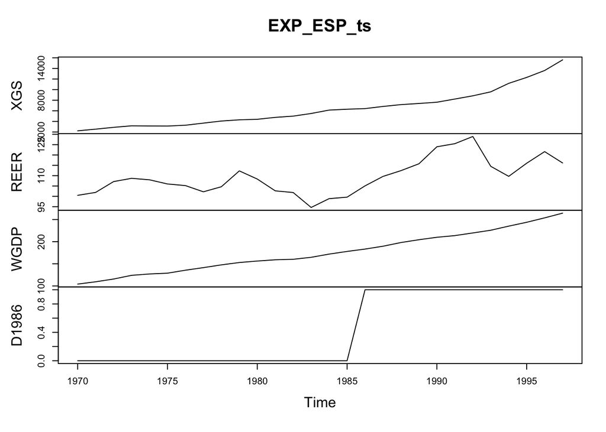

```r
# Formato de series temporales
EXP_ESP_ts <- ts(EXP_ESP[,2:5], start=c(1970), end = c(1997), frequency = 1)
plot(EXP_ESP_ts)
```

```r
# Ecuación de exportaciones para el período completo (1970-1997)
lm_X_ESP <- lm(log(XGS) ~ log(WGDP) + log(REER), data = EXP_ESP_ts)
summary(lm_X_ESP)
```

```
Call:
lm(formula = log(XGS) ~ log(WGDP) + log(REER), data = EXP_ESP_ts)

Residuals:
     Min       1Q   Median       3Q      Max
-0.08302 -0.04419 -0.02013  0.03883  0.14376

Coefficients:
            Estimate Std. Error t value Pr(>|t|)
(Intercept) -0.24239    0.84432  -0.287    0.776
log(WGDP)    2.04618    0.06235  32.820   <2e-16 ***
log(REER)   -0.34878    0.21480  -1.624    0.117
---
Signif. codes:  0 '***' 0.001 '**' 0.01 '*' 0.05 '.' 0.1 ' ' 1

Residual standard error: 0.06663 on 25 degrees of freedom
Multiple R-squared:  0.9853,    Adjusted R-squared:  0.9841
F-statistic: 836.6 on 2 and 25 DF,  p-value: < 2.2e-16
```

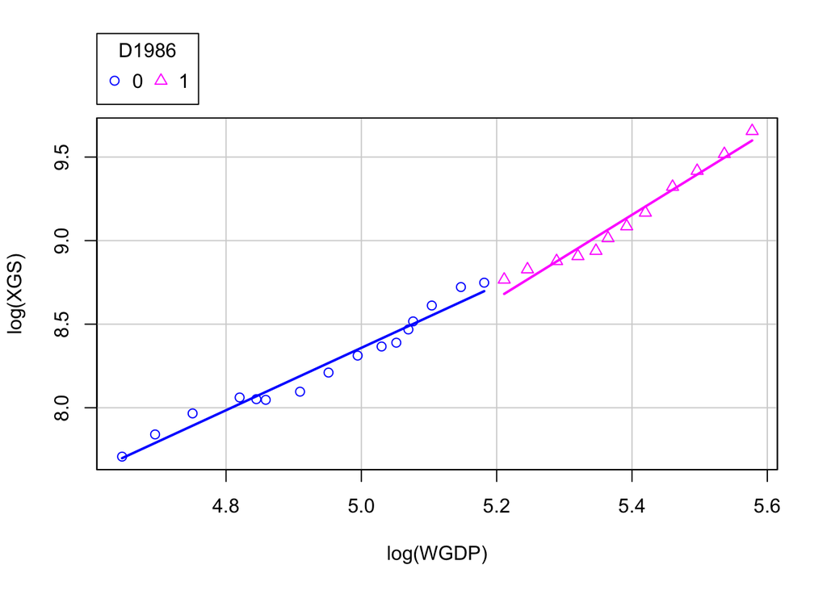

```r
# Gráficas parciales con diferenciación por subperíodos
scatterplot(log(XGS) ~ log(WGDP)| D1986, data=EXP_ESP_ts,
            smooth=FALSE, boxplots=FALSE,
            ylab="log(XGS)")
```

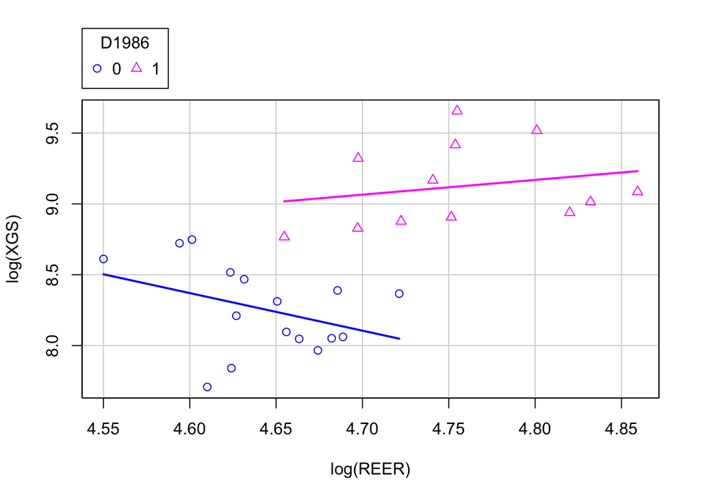

```r
scatterplot(log(XGS) ~ log(REER)| D1986, data=EXP_ESP_ts,
            smooth=FALSE, boxplots=FALSE,
            ylab="log(XGS)")
```

```r
# Diferenciación por subperíodos
# PreUE
preUE <- window(EXP_ESP_ts, start=1970, end = 1985)
lm_X_ESP_preUE <- lm(log(XGS) ~ log(WGDP) + log(REER) , data = preUE)
summary(lm_X_ESP_preUE)
```

```
Call:
lm(formula = log(XGS) ~ log(WGDP) + log(REER), data = preUE)

Residuals:
      Min        1Q    Median        3Q       Max
-0.085980 -0.029433  0.003653  0.027247  0.084831

Coefficients:
            Estimate Std. Error t value Pr(>|t|)
(Intercept)   2.5078     1.6493   1.520   0.1523
log(WGDP)     1.8144     0.0846  21.447 1.57e-11 ***
log(REER)    -0.6945     0.3187  -2.179   0.0483 *
---
Signif. codes:  0 '***' 0.001 '**' 0.01 '*' 0.05 '.' 0.1 ' ' 1

Residual standard error: 0.05124 on 13 degrees of freedom
Multiple R-squared:  0.9763,    Adjusted R-squared:  0.9727
F-statistic: 267.8 on 2 and 13 DF,  p-value: 2.725e-11
```

```r
# PostUE
postUE <- window(EXP_ESP_ts, start=1986, end = 1997)
lm_X_ESP_postUE <- lm(log(XGS) ~ log(WGDP) + log(REER) , data = postUE)
summary(lm_X_ESP_postUE)
```

```
Call:
lm(formula = log(XGS) ~ log(WGDP) + log(REER), data = postUE)

Residuals:
      Min        1Q    Median        3Q       Max
-0.052680 -0.032117  0.005373  0.029904  0.037074

Coefficients:
            Estimate Std. Error t value Pr(>|t|)
(Intercept)  -1.6788     0.8889  -1.889  0.09153 .
log(WGDP)     2.6425     0.1032  25.610 1.02e-09 ***
log(REER)    -0.7220     0.1933  -3.735  0.00466 **
---
Signif. codes:  0 '***' 0.001 '**' 0.01 '*' 0.05 '.' 0.1 ' ' 1

Residual standard error: 0.03661 on 9 degrees of freedom
Multiple R-squared:  0.9871,    Adjusted R-squared:  0.9842
F-statistic: 344.6 on 2 and 9 DF,  p-value: 3.133e-09
```

```r
# Comparación de coeficientes estimados
compareCoefs(lm_X_ESP_preUE,lm_X_ESP_postUE)
```

```
Calls:
1: lm(formula = log(XGS) ~ log(WGDP) + log(REER), data = preUE)
2: lm(formula = log(XGS) ~ log(WGDP) + log(REER), data = postUE)

            Model 1 Model 2
(Intercept)   2.508  -1.679
SE            1.649   0.889

log(WGDP)    1.8144  2.6425
SE           0.0846  0.1032

log(REER)    -0.694  -0.722
SE            0.319   0.193
```

```r
# ¿Existe diferenciación estadísticamente significativa por períodos?
# Test de Chow de cambio estructural
# Método 1 (ANOVA)
lm_X_EXP_int <- lm(log(XGS) ~ (log(WGDP) + log(REER))*D1986,
                   data = EXP_ESP_ts)
summary(lm_X_EXP_int)
```

```
Call:
lm(formula = log(XGS) ~ (log(WGDP) + log(REER)) * D1986, data = EXP_ESP_ts)

Residuals:
      Min        1Q    Median        3Q       Max
-0.085980 -0.030598  0.004582  0.029904  0.084831

Coefficients:
                Estimate Std. Error t value Pr(>|t|)
(Intercept)      2.50775    1.47498   1.700   0.1032
log(WGDP)        1.81445    0.07566  23.982  < 2e-16 ***
log(REER)       -0.69447    0.28504  -2.436   0.0234 *
D1986           -4.18659    1.84754  -2.266   0.0336 *
log(WGDP):D1986  0.82803    0.14968   5.532 1.47e-05 ***
log(REER):D1986 -0.02750    0.37389  -0.074   0.9420
---
Signif. codes:  0 '***' 0.001 '**' 0.01 '*' 0.05 '.' 0.1 ' ' 1

Residual standard error: 0.04583 on 22 degrees of freedom
Multiple R-squared:  0.9939,    Adjusted R-squared:  0.9925
F-statistic: 713.6 on 5 and 22 DF,  p-value: < 2.2e-16
```

```r
anova(lm_X_ESP, lm_X_EXP_int)
```

```
Analysis of Variance Table

Model 1: log(XGS) ~ log(WGDP) + log(REER)
Model 2: log(XGS) ~ (log(WGDP) + log(REER)) * D1986
  Res.Df      RSS Df Sum of Sq      F    Pr(>F)
1     25 0.110991
2     22 0.046204  3  0.064787 10.283 0.0001978 ***
---
Signif. codes:  0 '***' 0.001 '**' 0.01 '*' 0.05 '.' 0.1 ' ' 1
```

```r
# Método 2 (librería structchange)
library(strucchange)
sctest(log(XGS) ~ log(WGDP) + log(REER), data=EXP_ESP_ts,
       type = "Chow", point = Y1986-1)
```

```
    Chow test

data:  log(XGS) ~ log(WGDP) + log(REER)
F = 10.283, p-value = 0.0001978
```

```r
# Contrastes tipo Chow basados en estimaciones recursivas
# [se elimina un % de observaciones en los extremmos]
sbtest <- Fstats(log(XGS) ~ log(WGDP) + log(REER), data = EXP_ESP_ts,
                 from = 0.15, to = 0.85)
sbtest[["Fstats"]]
```

```
Time Series:
Start = 1973
End = 1992
Frequency = 1
 [1] 26.94858 40.37538 52.72550 53.14715 43.28653 41.27132 51.76225 53.52206
 [9] 43.97098 39.04442 33.07102 30.47271 30.84853 32.31100 37.23453 41.05085
[17] 41.68393 41.71401 38.20854 33.80421
```

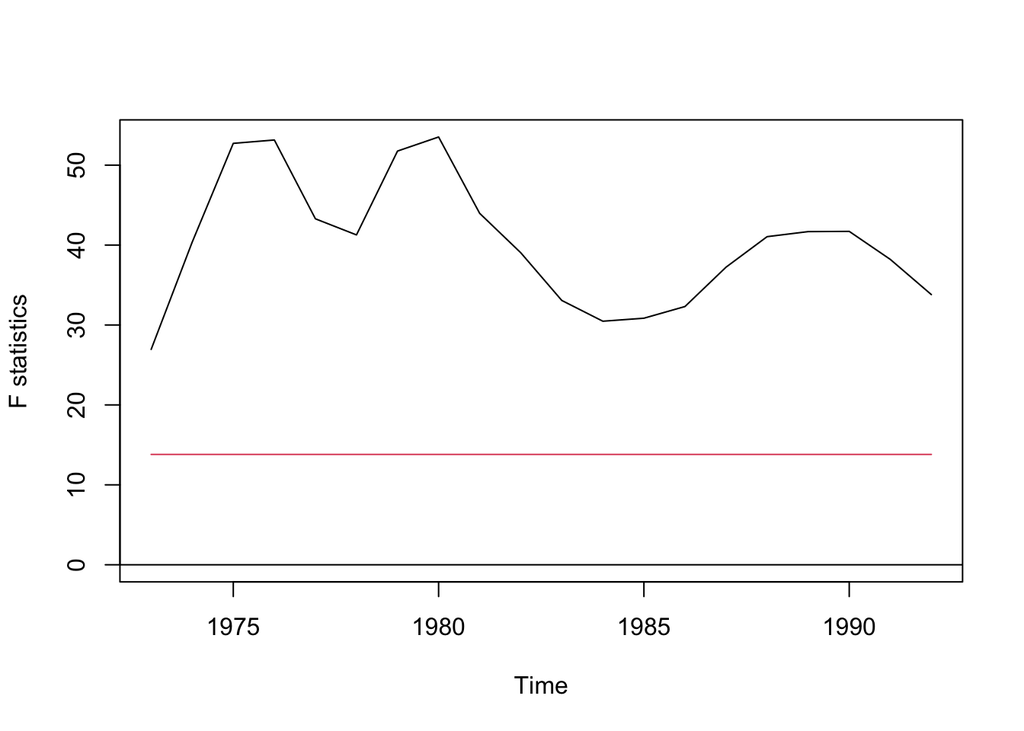

```r
plot(sbtest, alpha = 0.05)
```

```r
# Test de Chow (1960) [versión Chi2]
# [punto de ruptura conocido: 17 - 4 (15% suprimidos a la izquierda) ]
Chow_F <- sbtest$Fstats[Y1986-4]
Chow_F
```

```
[1] 30.84853
```

```r
# Se puede comprobar que CHOW=Chow_F/K
# Chow_F tiene una distribución asintótica Chi^2 mientras que
# CHOW tiene una distribución exacta F_K,T-2*K
pval <-  1-pchisq(Chow_F,sbtest$nreg)
pval
```

```
[1] 9.148179e-07
```

```r
# Contrastes de Andrews (1993) y Andrews y Ploberger (1994): supF, aveF, expF
# [punto de ruptura desconocido]
sctest(sbtest, type = "supF")
```

```
    supF test

data:  sbtest
sup.F = 53.522, p-value = 2.556e-10
```

```r
sctest(sbtest, type = "aveF")
```

```
    aveF test

data:  sbtest
ave.F = 40.323, p-value = 1.043e-13
```

```r
sctest(sbtest, type = "expF")
```

```
    expF test

data:  sbtest
exp.F = 24.845, p-value = 0.0007622
```

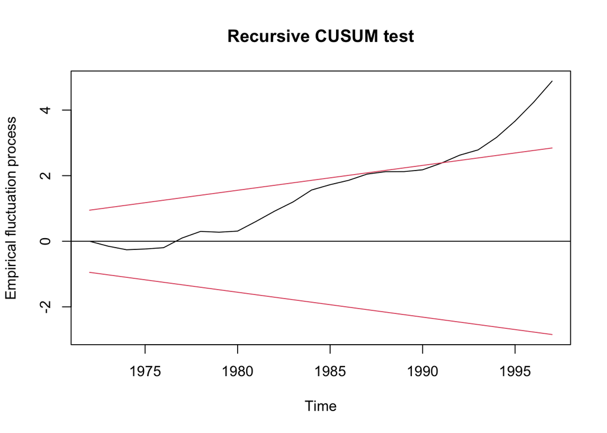

```r
# Test CUSUM (Brown, Durbin y Evans, 1975)
plot(efp(log(XGS) ~ log(WGDP) + log(REER), data = EXP_ESP_ts))
```

```r
# Regresión diferenciada por tramos temporales
summary(lm(log(XGS) ~ (log(WGDP) + log(REER))*D1986, data=EXP_ESP_ts))
```

```
Call:
lm(formula = log(XGS) ~ (log(WGDP) + log(REER)) * D1986, data = EXP_ESP_ts)

Residuals:
      Min        1Q    Median        3Q       Max
-0.085980 -0.030598  0.004582  0.029904  0.084831

Coefficients:
                Estimate Std. Error t value Pr(>|t|)
(Intercept)      2.50775    1.47498   1.700   0.1032
log(WGDP)        1.81445    0.07566  23.982  < 2e-16 ***
log(REER)       -0.69447    0.28504  -2.436   0.0234 *
D1986           -4.18659    1.84754  -2.266   0.0336 *
log(WGDP):D1986  0.82803    0.14968   5.532 1.47e-05 ***
log(REER):D1986 -0.02750    0.37389  -0.074   0.9420
---
Signif. codes:  0 '***' 0.001 '**' 0.01 '*' 0.05 '.' 0.1 ' ' 1

Residual standard error: 0.04583 on 22 degrees of freedom
Multiple R-squared:  0.9939,    Adjusted R-squared:  0.9925
F-statistic: 713.6 on 5 and 22 DF,  p-value: < 2.2e-16
```

**Código Python**

```python
# Lectura de librerías
import numpy as np
import pandas as pd
import matplotlib.pyplot as plt
import seaborn as sns
import scipy as sp
import statsmodels.api as sm
import statsmodels.formula.api as smf
import statsmodels.stats as smstats
# Lectura de datos
EXP_ESP = pd.read_csv("data/EXP_ESP_Y.csv", sep=";",
parse_dates=['date'], index_col='date')
date = pd.date_range(start = '1970', periods = len(EXP_ESP.index), freq = 'Y')
EXP_ESP.index = date
EXP_ESP.index
```

```
DatetimeIndex(['1970-12-31', '1971-12-31', '1972-12-31', '1973-12-31',
               '1974-12-31', '1975-12-31', '1976-12-31', '1977-12-31',
               '1978-12-31', '1979-12-31', '1980-12-31', '1981-12-31',
               '1982-12-31', '1983-12-31', '1984-12-31', '1985-12-31',
               '1986-12-31', '1987-12-31', '1988-12-31', '1989-12-31',
               '1990-12-31', '1991-12-31', '1992-12-31', '1993-12-31',
               '1994-12-31', '1995-12-31', '1996-12-31', '1997-12-31'],
              dtype='datetime64[ns]', freq='YE-DEC')
```

```python
EXP_ESP.info()
```

```
<class 'pandas.core.frame.DataFrame'>
DatetimeIndex: 28 entries, 1970-12-31 to 1997-12-31
Freq: YE-DEC
Data columns (total 3 columns):
 #   Column  Non-Null Count  Dtype
---  ------  --------------  -----
 0   XGS     28 non-null     float64
 1   REER    28 non-null     float64
 2   WGDP    28 non-null     float64
dtypes: float64(3)
memory usage: 896.0 bytes
```

```python
EXP_ESP.head()
```

```
                    XGS        REER        WGDP
1970-12-31  2225.123047  100.495876  104.200000
1971-12-31  2541.091064  101.909402  109.410000
1972-12-31  2881.596924  107.146269  115.646370
1973-12-31  3169.757080  108.713460  123.972908
1974-12-31  3138.059082  108.003898  127.072231
```

```python
EXP_ESP.tail()
```

```
                  XGS        REER        WGDP
1993-12-31   9579.586  114.520445  225.825635
1994-12-31  11181.767  109.674712  235.084486
1995-12-31  12299.895  116.021269  243.782612
1996-12-31  13604.854  121.631204  253.777699
1997-12-31  15611.863  116.142901  264.436363
```

```python
# Variables numérica y cualitativa de subperíodos
EXP_ESP['D1986'] = np.where(EXP_ESP.index > '1985-12-31', 1, 0)
EXP_ESP['UE']=EXP_ESP['D1986'].astype('category')
EXP_ESP['UE']=EXP_ESP['UE'].cat.rename_categories(['preUE', 'postUE'])
# Ecuación de exportaciones para el período completo (1970-1997)
lm_X_ESP = smf.ols(formula='np.log(XGS) ~ np.log(WGDP) + np.log(REER)',
data=EXP_ESP).fit()
print(lm_X_ESP.summary())
```

```
                            OLS Regression Results
==============================================================================
Dep. Variable:            np.log(XGS)   R-squared:                       0.985
Model:                            OLS   Adj. R-squared:                  0.984
Method:                 Least Squares   F-statistic:                     836.6
Date:                Sun, 09 Feb 2025   Prob (F-statistic):           1.26e-23
Time:                        13:52:12   Log-Likelihood:                 37.697
No. Observations:                  28   AIC:                            -69.39
Df Residuals:                      25   BIC:                            -65.40
Df Model:                           2
Covariance Type:            nonrobust
================================================================================
                   coef    std err          t      P>|t|      [0.025      0.975]
--------------------------------------------------------------------------------
Intercept       -0.2424      0.844     -0.287      0.776      -1.981       1.497
np.log(WGDP)     2.0462      0.062     32.820      0.000       1.918       2.175
np.log(REER)    -0.3488      0.215     -1.624      0.117      -0.791       0.094
==============================================================================
Omnibus:                        2.960   Durbin-Watson:                   0.290
Prob(Omnibus):                  0.228   Jarque-Bera (JB):                2.618
Skew:                           0.693   Prob(JB):                        0.270
Kurtosis:                       2.434   Cond. No.                         485.
==============================================================================

Notes:
[1] Standard Errors assume that the covariance matrix of the errors is correctly specified.
```

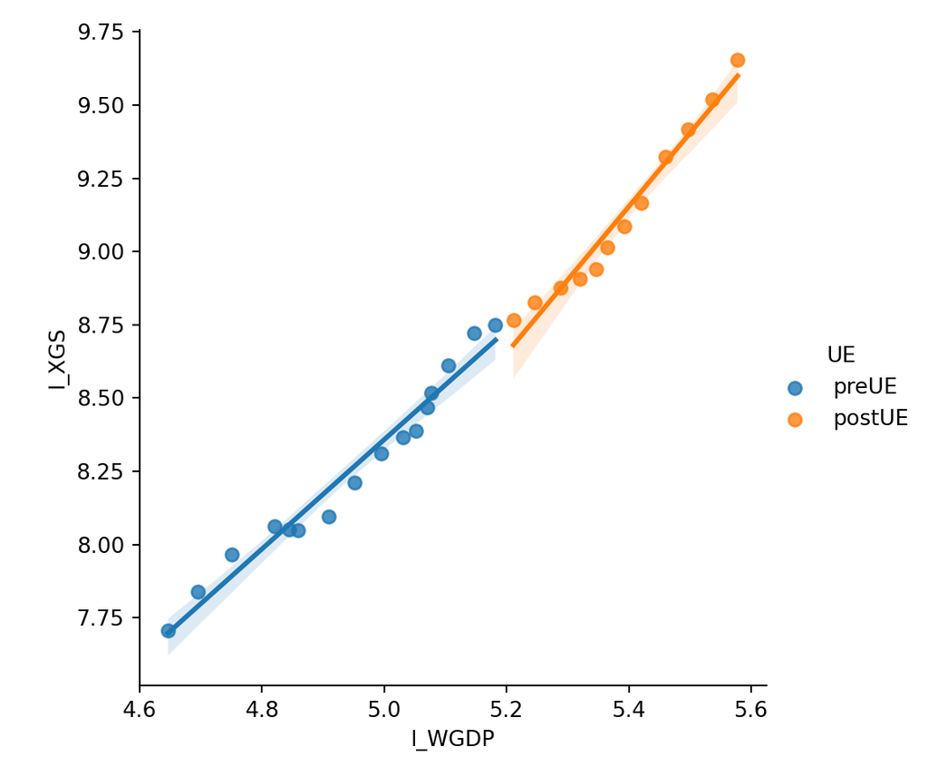

```python
# Gráficas parciales con diferenciación por subperíodos
EXP_ESP['l_XGS']=np.log(EXP_ESP['XGS'])
EXP_ESP['l_WGDP']=np.log(EXP_ESP['WGDP'])
EXP_ESP['l_REER']=np.log(EXP_ESP['REER'])
plt.figure(5)
sns.lmplot(x="l_WGDP", y="l_XGS", hue="UE", data=EXP_ESP);
plt.show()
```

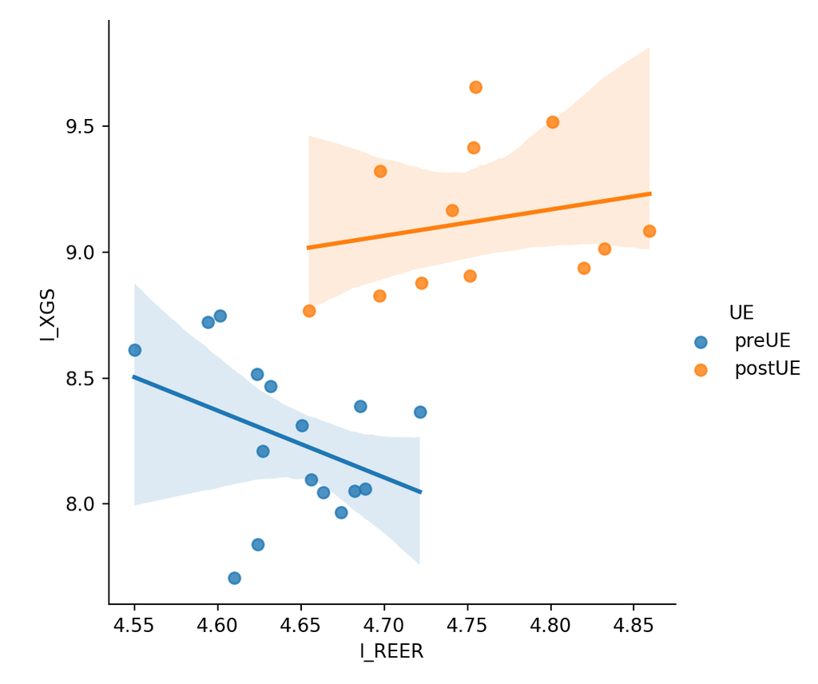

```python
plt.figure(6)
sns.lmplot(x="l_REER", y="l_XGS", hue="UE", data=EXP_ESP);
plt.show()
```

```python
# Diferenciación por subperíodos
# PreUE
lm_X_ESP_preUE = smf.ols(formula='np.log(XGS) ~ np.log(WGDP) + np.log(REER)',
subset=(EXP_ESP['D1986'] == 0), data=EXP_ESP).fit()
print(lm_X_ESP_preUE.summary())
```

```
                            OLS Regression Results
==============================================================================
Dep. Variable:            np.log(XGS)   R-squared:                       0.976
Model:                            OLS   Adj. R-squared:                  0.973
Method:                 Least Squares   F-statistic:                     267.8
Date:                Sun, 09 Feb 2025   Prob (F-statistic):           2.72e-11
Time:                        13:52:14   Log-Likelihood:                 26.496
No. Observations:                  16   AIC:                            -46.99
Df Residuals:                      13   BIC:                            -44.68
Df Model:                           2
Covariance Type:            nonrobust
================================================================================
                   coef    std err          t      P>|t|      [0.025      0.975]
--------------------------------------------------------------------------------
Intercept        2.5077      1.649      1.520      0.152      -1.055       6.071
np.log(WGDP)     1.8144      0.085     21.447      0.000       1.632       1.997
np.log(REER)    -0.6945      0.319     -2.179      0.048      -1.383      -0.006
==============================================================================
Omnibus:                        0.094   Durbin-Watson:                   0.755
Prob(Omnibus):                  0.954   Jarque-Bera (JB):                0.314
Skew:                           0.078   Prob(JB):                        0.855
Kurtosis:                       2.331   Cond. No.                         899.
==============================================================================

Notes:
[1] Standard Errors assume that the covariance matrix of the errors is correctly specified.
```

```python
# PostUE
lm_X_ESP_postUE = smf.ols(formula='np.log(XGS) ~ np.log(WGDP) + np.log(REER)',
subset=(EXP_ESP['D1986'] == 1), data=EXP_ESP).fit()
print(lm_X_ESP_postUE.summary())
```

```
                            OLS Regression Results
==============================================================================
Dep. Variable:            np.log(XGS)   R-squared:                       0.987
Model:                            OLS   Adj. R-squared:                  0.984
Method:                 Least Squares   F-statistic:                     344.6
Date:                Sun, 09 Feb 2025   Prob (F-statistic):           3.13e-09
Time:                        13:52:14   Log-Likelihood:                 24.386
No. Observations:                  12   AIC:                            -42.77
Df Residuals:                       9   BIC:                            -41.32
Df Model:                           2
Covariance Type:            nonrobust
================================================================================
                   coef    std err          t      P>|t|      [0.025      0.975]
--------------------------------------------------------------------------------
Intercept       -1.6788      0.889     -1.889      0.092      -3.690       0.332
np.log(WGDP)     2.6425      0.103     25.610      0.000       2.409       2.876
np.log(REER)    -0.7220      0.193     -3.735      0.005      -1.159      -0.285
==============================================================================
Omnibus:                        3.241   Durbin-Watson:                   1.134
Prob(Omnibus):                  0.198   Jarque-Bera (JB):                1.223
Skew:                          -0.318   Prob(JB):                        0.543
Kurtosis:                       1.572   Cond. No.                         620.
==============================================================================

Notes:
[1] Standard Errors assume that the covariance matrix of the errors is correctly specified.
```

```python
# Regresión diferenciada por tramos temporales
lm_X_ESP_int = smf.ols(formula='np.log(XGS) ~ (np.log(WGDP) + np.log(REER))*D1986',
data=EXP_ESP).fit()
print(lm_X_ESP_int.summary())
```

```
                            OLS Regression Results
==============================================================================
Dep. Variable:            np.log(XGS)   R-squared:                       0.994
Model:                            OLS   Adj. R-squared:                  0.992
Method:                 Least Squares   F-statistic:                     713.6
Date:                Sun, 09 Feb 2025   Prob (F-statistic):           1.46e-23
Time:                        13:52:14   Log-Likelihood:                 49.966
No. Observations:                  28   AIC:                            -87.93
Df Residuals:                      22   BIC:                            -79.94
Df Model:                           5
Covariance Type:            nonrobust
======================================================================================
                         coef    std err          t      P>|t|      [0.025      0.975]
--------------------------------------------------------------------------------------
Intercept              2.5077      1.475      1.700      0.103      -0.551       5.567
np.log(WGDP)           1.8144      0.076     23.982      0.000       1.658       1.971
np.log(REER)          -0.6945      0.285     -2.436      0.023      -1.286      -0.103
D1986                 -4.1866      1.848     -2.266      0.034      -8.018      -0.355
np.log(WGDP):D1986     0.8280      0.150      5.532      0.000       0.518       1.138
np.log(REER):D1986    -0.0275      0.374     -0.074      0.942      -0.803       0.748
==============================================================================
Omnibus:                        0.097   Durbin-Watson:                   0.854
Prob(Omnibus):                  0.953   Jarque-Bera (JB):                0.319
Skew:                           0.000   Prob(JB):                        0.853
Kurtosis:                       2.477   Cond. No.                     2.08e+03
==============================================================================

Notes:
[1] Standard Errors assume that the covariance matrix of the errors is correctly specified.
[2] The condition number is large, 2.08e+03. This might indicate that there are
strong multicollinearity or other numerical problems.
```

```python
# Test de Chow de cambio estructural
sm.stats.anova_lm(lm_X_ESP,lm_X_ESP_int)
```

```
   df_resid       ssr  df_diff   ss_diff          F    Pr(>F)
0      25.0  0.110991      0.0       NaN        NaN       NaN
1      22.0  0.046204      3.0  0.064787  10.282842  0.000198
```